# Reproducible Research: Peer Assignment 1

## Loading and preprocessing the data

```r
activity <- read.csv("activity.csv")
activity <- transform(activity, date = as.Date(date, "%Y-%m-%d"))
total = aggregate(activity$steps ~ activity$date, activity, sum)
```

## What is mean total number of steps taken per day?

### Histogram

The histogram of the number of steps taken per day is shown below.

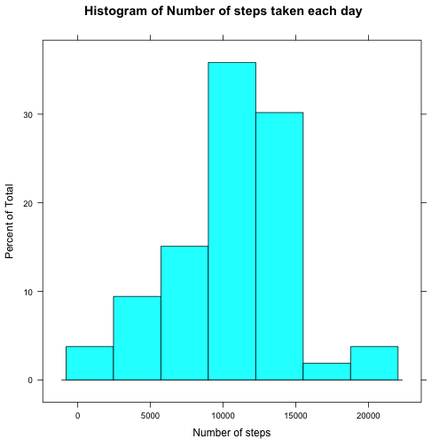

```r
library(lattice)
# Draw a histogram of the total number of steps taken each day
histogram(total[,2], xlab = "Number of steps", main="Histogram of Number of steps taken each day")
```

### Mean and median of total number of steps taken per day

The mean number of steps per day is 1.0766 × 10<sup>4</sup> while the median is 10765.

```r
# mean and median of number of steps taken per day
mean(total[,2], na.rm = TRUE)
```

```
## [1] 10766
```

```r
median(total[,2], na.rm = TRUE)
```

```
## [1] 10765
```

## Average daily activity pattern

### Time series plot

Plot of the time series of the 5-minute interval (x-axis) and the average number of steps taken, averaged across all days (y-axis).

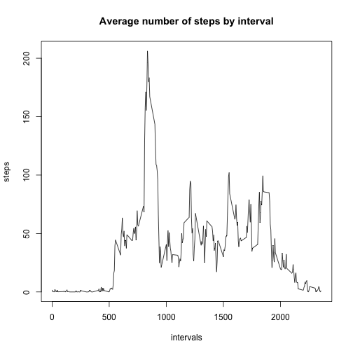

```r
intervals = aggregate(activity$steps ~ activity$interval, activity, mean)
plot(intervals[ ,1], intervals[ ,2], type = "l", xlab = "intervals", ylab = "steps", main = "Average number of steps by interval")
```

### Which 5-minute interval, on average across all the days in the dataset, contains the maximum number of steps?

The 5-minute interval with maximum number of steps is interval 835.

## Imputing missing values

### Total number of missing values in the dataset

The total number of missing values in the dataset is 2304.

### Filling in all of the missing values in the dataset.

A new dataset is created. It is equal to the original dataset but where the missing data is replaced by the mean of the 5-minute interval.

```r
newactivity = activity
for (k in 1:nrow(activity)){
  newactivity[k, 1] = ifelse(is.na(activity[k, 1]), intervals[which(intervals[ ,1] == activity[k, 3]), 2], activity[k, 1])
}
```

Check to see if all values have been replaced: total number of missing values in the newactivity dataset is 0.

### Histogram, mean and median of total number of steps

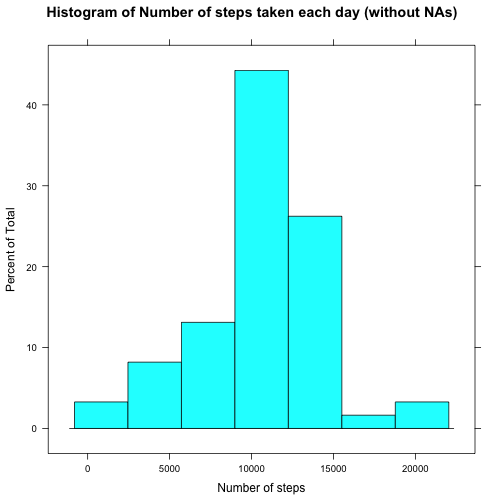

```r
total_new = aggregate(newactivity$steps ~ newactivity$date, newactivity, sum)
library(lattice)
histogram(total_new[,2], xlab = "Number of steps", main="Histogram of Number of steps taken each day (without NAs)")
```

The mean number of steps per day is 1.0766 × 10<sup>4</sup> while the median is 1.0766 × 10<sup>4</sup>.

```r
# mean and median of number of steps taken per day
mean(total_new[,2], na.rm = TRUE)
```

```
## [1] 10766
```

```r
median(total_new[,2], na.rm = TRUE)
```

```
## [1] 10766
```

The mean and median are the same as before (just a one unit difference for the median). This is due to the fact that I have allocated more weight to the mean (because of the imputation of missing data).

## Differences in activity patterns between weekdays and weekends?

I compare the average number of steps during the weekend and the weekdays. As can be seen from the plot below, there are more steps during weekends than during weekdays.

```r
newactivity$date = as.Date(newactivity$date)
newactivity$date = strptime(newactivity$date, format="%Y-%m-%d")

for (k in 1:nrow(newactivity)){
  newactivity$weekday[k] = ifelse(weekdays(newactivity$date[k]) == "Saturday" | weekdays(newactivity$date[k]) == "Sunday",  "weekend", "weekday")
}
activity_weekday = newactivity[newactivity$weekday == "weekday", ]
activity_weekend = newactivity[newactivity$weekday == "weekend", ]
intervalweekday = aggregate(activity_weekday$steps ~ activity_weekday$interval, activity_weekday, mean)
intervalweekend = aggregate(activity_weekend$steps ~ activity_weekend$interval, activity_weekend, mean)
```

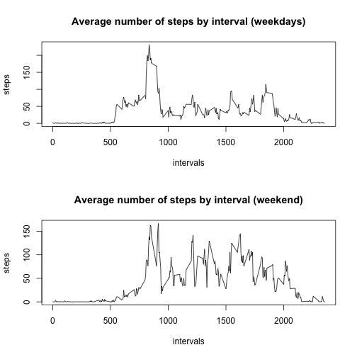

```r
par(mfrow=c(2,1))
plot(intervalweekday[ ,1], intervalweekday[ ,2], type = "l", xlab = "intervals", ylab = "steps", main = "Average number of steps by interval (weekdays)")
plot(intervalweekend[ ,1], intervalweekend[ ,2], type = "l", xlab = "intervals", ylab = "steps", main = "Average number of steps by interval (weekend)")
```